# Άσκηση 2 - Ανάλυση Βροχόπτωσης Καλαμάτας

2026-06-14

# 1 Εισαγωγή

Η παρούσα ανάλυση εξετάζει τη μηνιαία βροχόπτωση (mm) στην Καλαμάτα για την περίοδο **2016–2025**, χρησιμοποιώντας δεδομένα από την Ελληνική Μετεωρολογική Υπηρεσία (ΕΜΥ). Στόχος είναι η προσαρμογή μοντέλου **SARIMA** μέσω της μεθοδολογίας Box-Jenkins.

# 2 Φόρτωση Βιβλιοθηκών

```r
library(forecast)  # Για SARIMA μοντέλα και προβλέψεις
library(tseries)   # Για ADF και KPSS ελέγχους
library(uroot)     # Για Canova-Hansen test
```

# 3 Φόρτωση & Προετοιμασία Δεδομένων

```r
# Φόρτωση CSV αρχείου ΕΜΥ
data <- read.csv("emi.csv", sep = ";", na.strings = "NA")

# Μετονομασία στηλών
colnames(data) <- c("ETOS", "MINAS", "RR")

# Αντικατάσταση ελλειπουσών τιμών με εποχικό μέσο
# Εντοπίστηκαν 5 NA: Νοέμβριος 2016, Μάιος 2021,
# Ιούνιος & Ιούλιος 2024, Ιούνιος 2025
for(i in which(is.na(data$RR))) {
  minas <- data$MINAS[i]
  data$RR[i] <- round(mean(data$RR[data$MINAS == minas], na.rm = TRUE))
}

cat("Αριθμός NA μετά αντικατάσταση:", sum(is.na(data$RR)), "\n")
```

```
## Αριθμός NA μετά αντικατάσταση: 0
```

```r
# Δημιουργία χρονοσειράς: μηνιαία από Ιανουάριο 2016
ts_rr <- ts(data$RR, start = c(2016, 1), frequency = 12)

cat("Πλήθος παρατηρήσεων:", length(ts_rr), "\n")
```

```
## Πλήθος παρατηρήσεων: 120
```

```r
print(ts_rr)
```

```
##      Jan Feb Mar Apr May Jun Jul Aug Sep Oct Nov Dec
## 2016 102  21  72   6  34  80   0  17 158  77 131   9
## 2017 175  37  40   9  26   6  59   2   7  47 167 109
## 2018  86 162  33   5  42  80   6  12  61  19 153 103
## 2019 300  58  42  77  15  13  22   0  21  25 189 111
## 2020  18  32  40  21  16   0  28   1  71  66  12 192
## 2021 109  24  48   3  26   4   0   0  28  93  55  36
## 2022  32  65  56  32  17  41  88   5  52  34 160  71
## 2023 109   9  58  37  41   4   0  18  31  57 148  66
## 2024 118  36  77  16  22  28  23  19  52   0 104 148
## 2025 166  88  47  27  20  28   0   0  18 111 195 172
```

# 4 Χρονοδιάγραμμα Αρχικής Σειράς

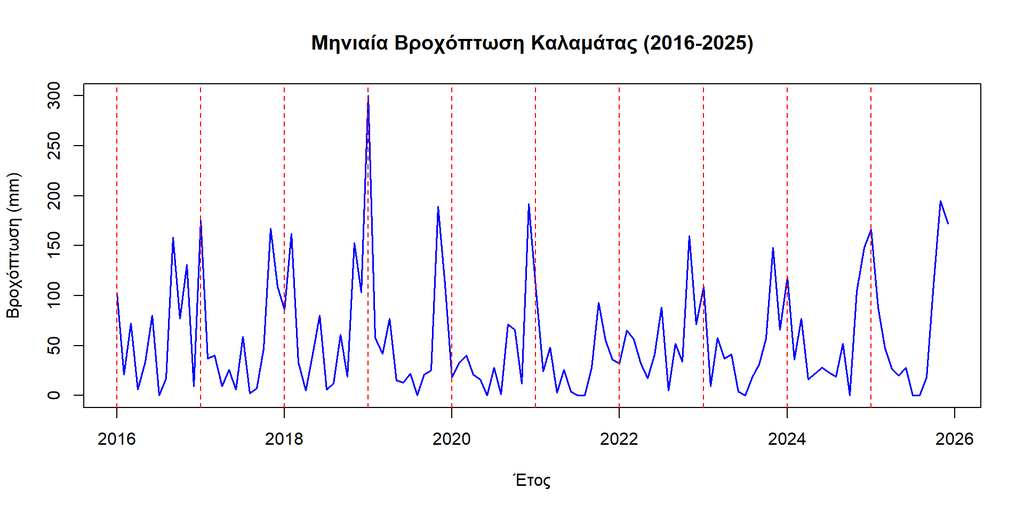

```r
plot(ts_rr,
     main = "Μηνιαία Βροχόπτωση Καλαμάτας (2016-2025)",
     xlab = "Έτος",
     ylab = "Βροχόπτωση (mm)",
     col = "blue",
     lwd = 1.5,
     type = "l")
abline(v = 2016:2025, col = "red", lty = 2)
```

**Παρατηρήσεις:**

- Έντονη εποχικότητα με περίοδο s = 12 μήνες (βροχερός χειμώνας / ξηρό καλοκαίρι)
- Χαρακτηριστικό Μεσογειακό κλίμα
- Ακραία τιμή Ιανουάριος 2019: ~300mm
- Δεν παρατηρείται μακροχρόνια τάση ανόδου ή καθόδου
- **Συμπέρασμα:** Η σειρά κρίνεται μη στάσιμη λόγω εποχικότητας

# 5 Έλεγχος Στασιμότητας Αρχικής Σειράς

## 5.1 Έλεγχος KPSS

```r
# H0: Η σειρά είναι στάσιμη (απουσία τάσης)
# p > 0.05 → δεν απορρίπτουμε H0 → d = 0
kpss.test(ts_rr, null = "Trend")
```

```
##
##  KPSS Test for Trend Stationarity
##
## data:  ts_rr
## KPSS Trend = 0.056165, Truncation lag parameter = 4, p-value = 0.1
```

> **Αποτέλεσμα:** p = 0.1 > 0.05 → Απουσία τάσης → **d = 0**

## 5.2 Έλεγχος ADF

```r
# ΠΡΟΣΟΧΗ: Ο ADF δεν είναι ευαίσθητος στην εποχική μη στασιμότητα
adf.test(ts_rr)
```

```
##
##  Augmented Dickey-Fuller Test
##
## data:  ts_rr
## Dickey-Fuller = -6.1114, Lag order = 4, p-value = 0.01
## alternative hypothesis: stationary
```

> **Αποτέλεσμα:** p < 0.01 — Παραπλανητικά στάσιμη λόγω γρήγορης επιστροφής στο μέσο. Ο ADF δεν αρκεί εδώ.

## 5.3 Έλεγχος Canova-Hansen

```r
# Ελέγχει αν υπάρχει σταθερή (ντετερμινιστική) εποχικότητα
# H0: Σταθερή εποχικότητα
# p > 0.05 → σταθερή εποχικότητα → D = 1
ch.test(ts_rr)
```

```
##
##  Canova and Hansen test for seasonal stability
##
## data:  ts_rr
##
##       statistic pvalue
## Jan      0.0921 0.7398
## Feb       0.088 0.7632
## Mar      0.2106 0.2954
## Apr      0.1006 0.6937
## May      0.1308 0.5509
## Jun      0.2203 0.2737
## Jul      0.0625 0.9112
## Aug      0.1091 0.6503
## Sep      0.2362 0.2418
## Oct      0.0755 0.8355
## Nov      0.1039 0.6766
## Dec      0.1867 0.3568
## joint    1.4523 0.5179
## ---
## Signif. codes: 0 '***' 0.001 '**' 0.01 '*' 0.05 '.' 0.1 ' ' 1
##
## Test type: seasonal dummies
## NW covariance matrix lag order: 13
## First order lag: no
## Other regressors: no
## P-values: based on response surface regressions
```

> **Αποτέλεσμα:** p = 0.52 > 0.05 → Σταθερή εποχικότητα → **D = 1**

## 5.4 ACF & PACF Αρχικής Σειράς

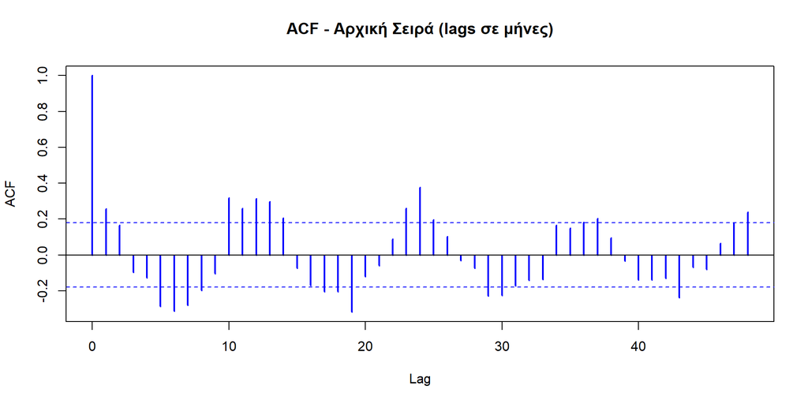

```r
# Εναλλασσόμενο πρόσημο (+/-) = χαρακτηριστικό εποχικής μη στάσιμης σειράς
acf(as.numeric(ts_rr), lag.max = 48,
    main = "ACF - Αρχική Σειρά (lags σε μήνες)",
    col = "blue", lwd = 2)
```

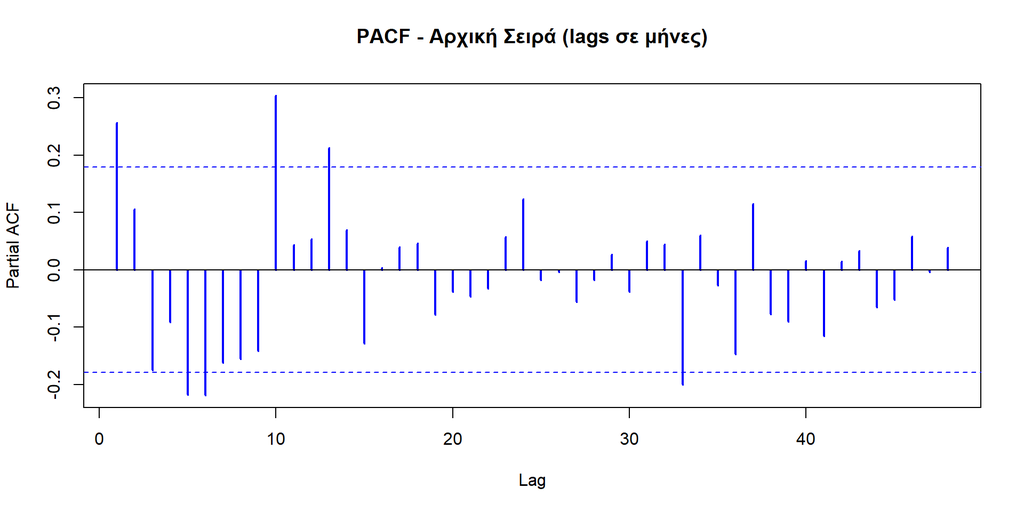

```r
# Σημαντικές ράβδοι στα lags 1, 5-6, 10, 13
# Δεν υπάρχει καθαρή αποκοπή → επιβεβαιώνει μη στασιμότητα
pacf(as.numeric(ts_rr), lag.max = 48,
     main = "PACF - Αρχική Σειρά (lags σε μήνες)",
     col = "blue", lwd = 2)
```

> **Συμπέρασμα:** Η μη στασιμότητα οφείλεται αποκλειστικά στην εποχικότητα. Προχωράμε σε εποχικές διαφορές με **d = 0, D = 1**.

# 6 Εποχικές Διαφορές

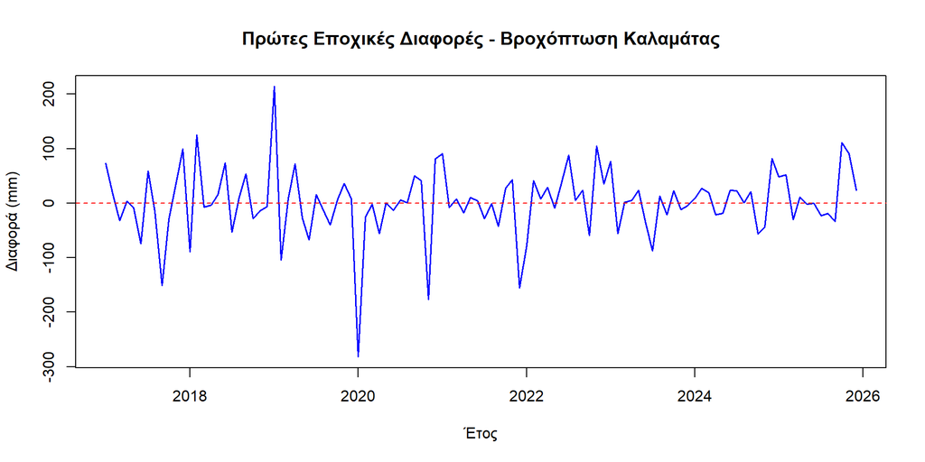

```r
# Εποχική διαφορά lag=12: αφαιρούμε από κάθε μήνα
# την αντίστοιχη τιμή του προηγούμενου έτους
ts_sdiff <- diff(ts_rr, lag = 12)

plot(ts_sdiff,
     main = "Πρώτες Εποχικές Διαφορές - Βροχόπτωση Καλαμάτας",
     xlab = "Έτος",
     ylab = "Διαφορά (mm)",
     col = "blue", lwd = 1.5)
abline(h = 0, col = "red", lty = 2)
```

**Παρατήρηση:** Οι τιμές κυμαίνονται γύρω από το 0 χωρίς τάση ή εποχικό μοτίβο → πρώτη ένδειξη στασιμότητας.

## 6.1 ACF & PACF Εποχικών Διαφορών

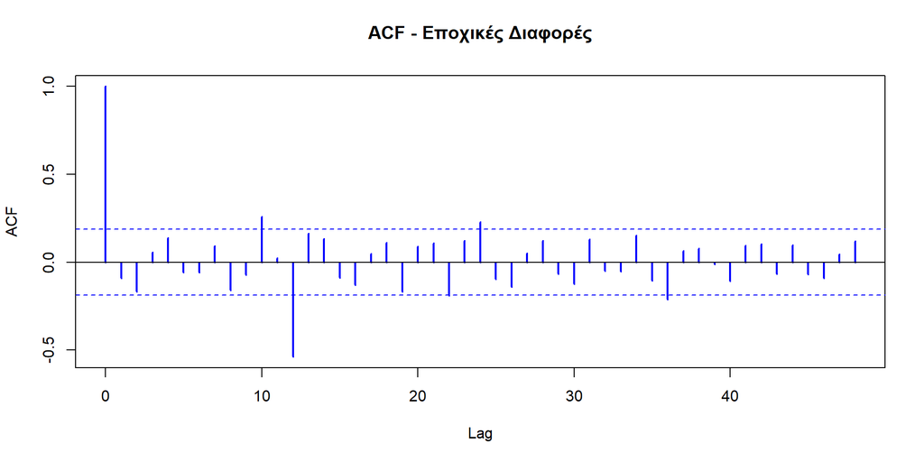

```r
# lag 12 εκτός αρνητικά → εποχικό MA(1), Q = 1
acf(as.numeric(ts_sdiff), lag.max = 48,
    main = "ACF - Εποχικές Διαφορές",
    col = "blue", lwd = 2)
```

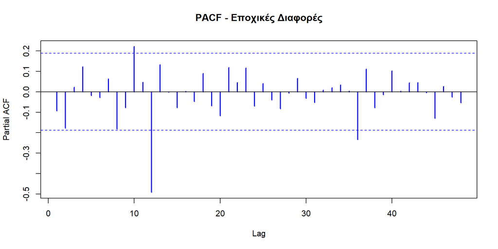

```r
# lag εντός → δεν χρειάζεται AR, p = 0
# lag 12 εκτός αρνητικά → εποχικό AR(1), P = 1
pacf(as.numeric(ts_sdiff), lag.max = 48,
     main = "PACF - Εποχικές Διαφορές",
     col = "blue", lwd = 2)
```

## 6.2 Έλεγχοι Στασιμότητας Εποχικών Διαφορών

```r
adf.test(ts_sdiff)
```

```
##
##  Augmented Dickey-Fuller Test
##
## data:  ts_sdiff
## Dickey-Fuller = -4.1803, Lag order = 4, p-value = 0.01
## alternative hypothesis: stationary
```

```r
ch.test(ts_sdiff)
```

```
##
##  Canova and Hansen test for seasonal stability
##
## data:  ts_sdiff
##
##       statistic pvalue
## Jan      0.0518 0.9708
## Feb      0.0789 0.8279
## Mar      0.1704 0.4157
## Apr      0.0567 0.9512
## May      0.0506  0.976
## Jun      0.0925 0.7502
## Jul       0.068 0.8914
## Aug      0.1067 0.6748
## Sep      0.1317 0.5595
## Oct      0.1401 0.5253
## Nov       0.091 0.7588
## Dec      0.0903 0.7625
## joint     1.123 0.6272
## ---
## Signif. codes: 0 '***' 0.001 '**' 0.01 '*' 0.05 '.' 0.1 ' ' 1
##
## Test type: seasonal dummies
## NW covariance matrix lag order: 12
## First order lag: no
## Other regressors: no
## P-values: based on response surface regressions
```

> **Αποτελέσματα:** ADF p < 0.01 → Στάσιμη | Canova-Hansen p = 0.63 → Εποχικότητα αφαιρέθηκε

# 7 Προσαρμογή SARIMA Μοντέλου

Βάσει ανάλυσης ACF/PACF εποχικών διαφορών:

| Παράμετρος | Τιμή | Αιτιολογία |
| --- | --- | --- |
| p | 0 | Αρχικά lag εντός στο PACF |
| d | 0 | KPSS: απουσία τάσης |
| q | 0 | Αρχικά lag εντός στο ACF |
| P | 1 | lag 12 εκτός στο PACF |
| D | 1 | Μία εποχική διαφορά |
| Q | 1 | lag 12 εκτός στο ACF |
| s | 12 | Μηνιαία δεδομένα |

## 7.1 Αρχικό Μοντέλο: SARIMA(0,0,0)(1,1,1)[12]

```r
model_manual <- arima(ts_rr,
                      order = c(0, 0, 0),
                      seasonal = list(order = c(1, 1, 1), period = 12))
print(model_manual)
```

```
##
## Call:
## arima(x = ts_rr, order = c(0, 0, 0), seasonal = list(order = c(1, 1, 1), period = 12))
##
## Coefficients:
##          sar1     sma1
##       -0.1709  -1.0000
## s.e.   0.1055   0.1512
##
## sigma^2 estimated as 1649:  log likelihood = -568.96,  aic = 1143.93
```

## 7.2 Σύγκριση με auto.arima

```r
model_auto <- auto.arima(ts_rr,
                         seasonal = TRUE,
                         stepwise = FALSE,
                         approximation = FALSE)
print(model_auto)
```

```
## Series: ts_rr
## ARIMA(0,0,0)(2,0,0)[12] with non-zero mean
##
## Coefficients:
##         sar1    sar2     mean
##       0.2280  0.4071  57.9355
## s.e.  0.0825  0.0891   9.4791
##
## sigma^2 = 2306:  log likelihood = -636.48
## AIC=1280.96   AICc=1281.31   BIC=1292.11
```

## 7.3 Σύγκριση Μοντέλων

```r
cat("=== Σύγκριση Μοντέλων ===\n")
```

```
## === Σύγκριση Μοντέλων ===
```

```r
cat("SARIMA(0,0,0)(1,1,1)[12] sigma²:", 1649, "| Ljung-Box p:", 0.867, "\n")
```

```
## SARIMA(0,0,0)(1,1,1)[12] sigma²: 1649 | Ljung-Box p: 0.867
```

```r
cat("auto.arima            sigma²:", 2306, "| Ljung-Box p:", 0.053, "\n")
```

```
## auto.arima            sigma²: 2306 | Ljung-Box p: 0.053
```

```r
cat("SARIMA(0,0,0)(1,1,1)[12] AIC:", AIC(model_manual), "\n")
```

```
## SARIMA(0,0,0)(1,1,1)[12] AIC: 1143.93
```

```r
cat("auto.arima            AIC:", AIC(model_auto), "\n")
```

```
## auto.arima            AIC: 1280.962
```

> **Συμπέρασμα:** Το SARIMA(0,0,0)(1,1,1)[12] επιλέγεται βάσει μικρότερης διακύμανσης σφαλμάτων (sigma²=1649 vs 2306) και καλύτερου Ljung-Box (p=0.867 vs p=0.053). Τα AIC δεν συγκρίνονται απευθείας λόγω διαφορετικού D.

# 8 Έλεγχος Καταλοίπων

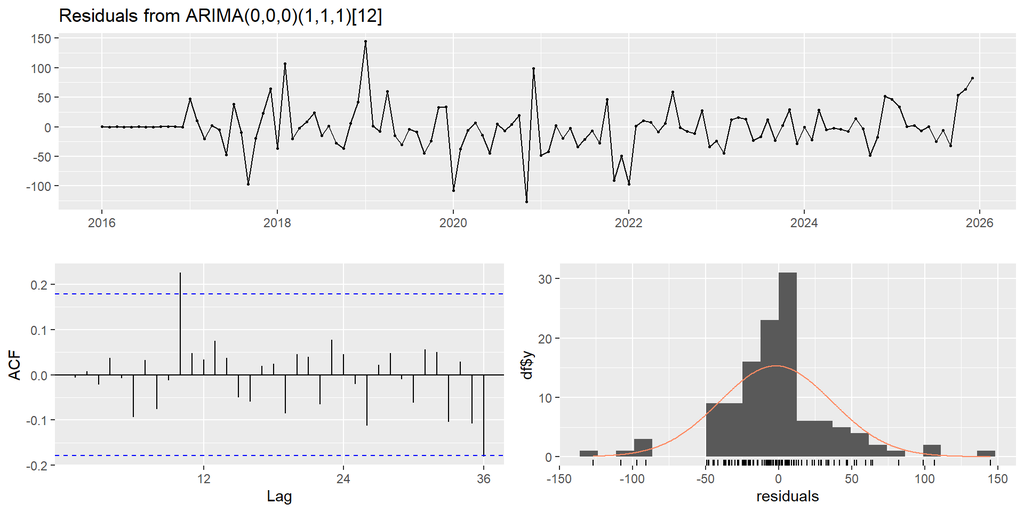

```
##
##  Ljung-Box test
##
## data:  Residuals from ARIMA(0,0,0)(1,1,1)[12]
## Q* = 14.88, df = 22, p-value = 0.8674
##
## Model df: 2.   Total lags used: 24
```

```r
checkresiduals(model_manual)
```

> **Ljung-Box:** Q* = 14.88, df = 22, **p = 0.867 >> 0.05** → Τα κατάλοιπα είναι λευκός θόρυβος → Το μοντέλο είναι κατάλληλο

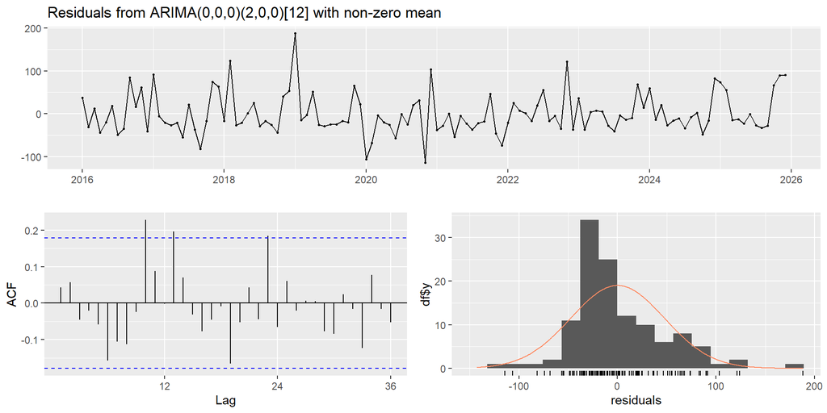

```
##
##  Ljung-Box test
##
## data:  Residuals from ARIMA(0,0,0)(2,0,0)[12] with non-zero mean
## Q* = 33.652, df = 22, p-value = 0.05327
##
## Model df: 2.   Total lags used: 24
```

```r
# Σύγκριση με auto.arima
checkresiduals(model_auto)
```

> **auto.arima Ljung-Box:** p = 0.053 — οριακά αποδεκτό. Επιβεβαιώνεται η υπεροχή του SARIMA(0,0,0)(1,1,1)[12].

# 9 Πρόβλεψη 12 Μηνών

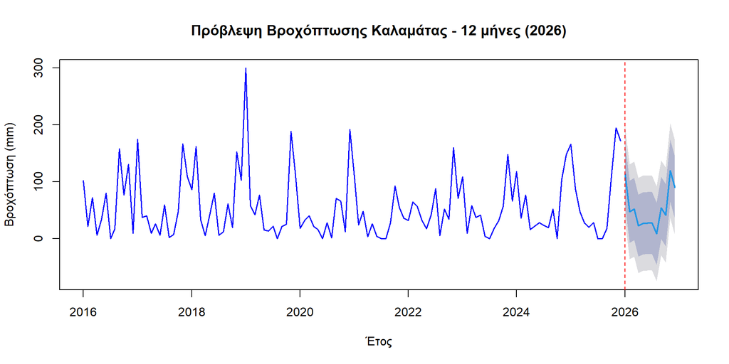

```r
# Πρόβλεψη για το 2026
forecast_model <- forecast(model_manual, h = 12)

plot(forecast_model,
     main = "Πρόβλεψη Βροχόπτωσης Καλαμάτας - 12 μήνες (2026)",
     xlab = "Έτος",
     ylab = "Βροχόπτωση (mm)",
     col = "blue", lwd = 1.5)
abline(v = 2026, col = "red", lty = 2)
```

# 10 Συμπεράσματα

| **Βέλτιστο Μοντέλο** | SARIMA(0,0,0)(1,1,1)[12] |
| --- | --- |
| **AIC** | 1143.93 |
| **sigma²** | 1649 |
| **Ljung-Box p-value** | 0.867 |
| **Παράμετροι** | d=0, D=1, s=12 |

- Η βροχόπτωση Καλαμάτας ακολουθεί σταθερό Μεσογειακό κλιματικό μοτίβο χωρίς μακροχρόνια αλλαγή τάσης
- Η ακραία τιμή Ιανουαρίου 2019 (300mm) αποτελεί σπάνιο κλιματικό γεγονός
- Το μοντέλο είναι κατάλληλο και αξιόπιστο για βραχυπρόθεσμη πρόβλεψη